# Application 1: Effective Use of Position and Scales

Author

Erik Westlund

Published

June 12, 2025

## Introduction

This notebook demonstrates how axis scaling and data presentation can be used effectively or to mislead. We’ll explore how to use positions and scales to make data more understandable, particularly with respect to magnitudes.

We’ll explore two main techniques to mislead:

1. Truncated axes in bar plots that exaggerate small differences
2. Selective time windows in time series that create misleading trends

## Position, Scale, and Magnitude

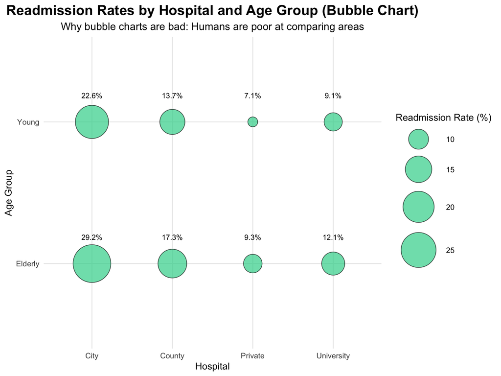

```r
set.seed(123)
n <- 1000

# Create simulated patient data with more distinct patterns
patient_data <- data.frame(
  patient_id = 1:n,
  treatment = sample(c("Standard", "New"), n, replace = TRUE),
  age_group = sample(c("Young", "Elderly"), n, replace = TRUE),
  hospital = sample(c("City", "County", "University", "Private"), n, replace = TRUE)
)

# Create more distinct base rates by hospital
hospital_effects <- c(
  "City" = 0.25,      # Higher rates in city hospitals
  "County" = 0.15,    # Moderate rates in county hospitals
  "University" = 0.10, # Lower rates in university hospitals
  "Private" = 0.08    # Lowest rates in private hospitals
)

# Add random variation and treatment/age effects
patient_data$readmission_rate <- vapply(1:n, function(i) {
  h <- patient_data$hospital[i]
  base_rate <- hospital_effects[h]
  # Add some random variation
  rate <- base_rate + rnorm(1, 0, 0.02)
  # Treatment effect (20% reduction for new treatment)
  rate <- rate * ifelse(patient_data$treatment[i] == "New", 0.8, 1)
  # Age effect (30% increase for elderly)
  rate <- rate * ifelse(patient_data$age_group[i] == "Elderly", 1.3, 1)
  return(rate)
}, numeric(1))

# Ensure rates stay between 0 and 1
patient_data$readmission_rate <- pmin(pmax(patient_data$readmission_rate, 0), 1)

# Create summary data for bubble chart
bubble_data <- patient_data |>
  group_by(hospital, age_group) |>
  summarize(
    readmission_rate = mean(readmission_rate),
    patient_count = n(),
    .groups = "drop"
  )

# 0. Worst Example: Bubble Chart (Area/Volume)
ggplot(bubble_data, aes(x = hospital, y = age_group)) +
  geom_point(
    aes(size = readmission_rate * 100),  # Scale up for better visibility
    shape = 21,
    fill = "#34D399",
    color = "black",
    alpha = 0.7
  ) +
  geom_text(
    aes(label = sprintf("%.1f%%", readmission_rate * 100)),
    size = 3,
    vjust = -4.5
  ) +
  scale_size_continuous(
    range = c(5, 20),
    name = "Readmission Rate (%)"
  ) +
  labs(
    title = "Readmission Rates by Hospital and Age Group (Bubble Chart)",
    subtitle = "Why bubble charts are bad: Humans are poor at comparing areas",
    x = "Hospital",
    y = "Age Group"
  ) +
  theme_minimal() +
  theme(
    plot.title = element_text(hjust = 0.5, face = "bold", size = 16),
    plot.subtitle = element_text(hjust = 0.5, size = 12),
    legend.position = "right"
  )
```

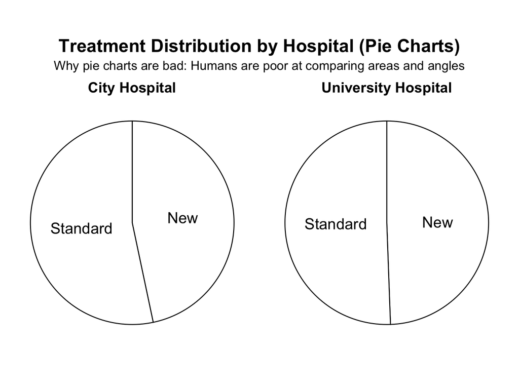

```r
# 1. Area/Volume (Why pie charts are bad)
pie_data <- patient_data |>
  group_by(hospital, treatment) |>
  summarize(
    count = n(),
    .groups = "drop"
  ) |>
  group_by(hospital) |>
  mutate(
    total = sum(count),
    proportion = count / total,
    label = treatment
  ) |>
  group_by(hospital) |>
  mutate(position = cumsum(proportion) - (proportion / 2)) |>
  ungroup()

# Create pie charts
standard_pie <- pie_data |>
  filter(hospital == "City") |>
  ggplot(aes(x = "", y = proportion, fill = treatment)) +
  geom_bar(stat = "identity", width = 1, color = "black", fill = "white") +
  coord_polar(theta = "y") +
  geom_text(aes(y = position, label = label), size = 6) +
  labs(
    title = "City Hospital",
    x = NULL,
    y = NULL
  ) +
  theme_void() +
  theme(
    legend.position = "none",
    plot.title = element_text(hjust = 0.5, face = "bold", size = 16)
  )

university_pie <- pie_data |>
  filter(hospital == "University") |>
  ggplot(aes(x = "", y = proportion, fill = treatment)) +
  geom_bar(stat = "identity", width = 1, color = "black", fill = "white") +
  coord_polar(theta = "y") +
  geom_text(aes(y = position, label = label), size = 6) +
  labs(
    title = "University Hospital",
    x = NULL,
    y = NULL
  ) +
  theme_void() +
  theme(
    legend.position = "none",
    plot.title = element_text(hjust = 0.5, face = "bold", size = 16)
  )

# Display pie charts
(standard_pie + university_pie) +
  plot_annotation(
    title = "Treatment Distribution by Hospital (Pie Charts)",
    subtitle = "Why pie charts are bad: Humans are poor at comparing areas and angles",
    theme = theme(
      plot.title = element_text(hjust = 0.5, face = "bold", size = 20),
      plot.subtitle = element_text(hjust = 0.5, size = 14)
    )
  )
```

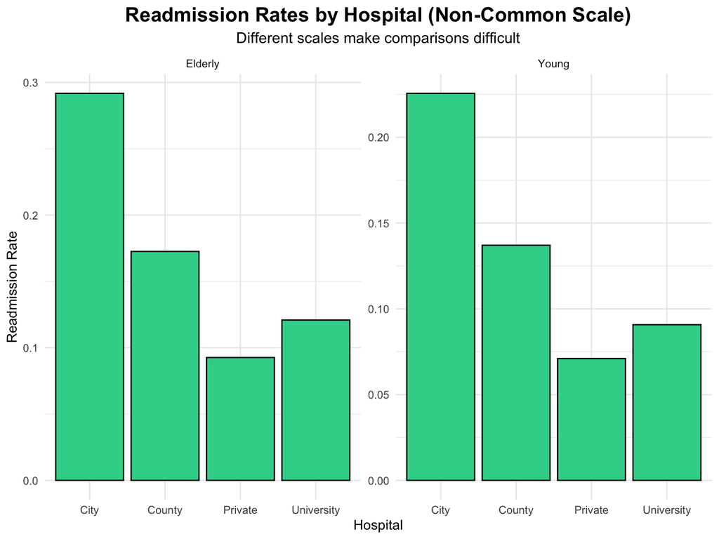

```r
# 2. Position on non-common scale
ggplot(patient_data, aes(x = hospital, y = readmission_rate)) +
  geom_bar(stat = "summary", fun = "mean", fill = "#34D399", color = "black") +
  facet_wrap(~ age_group, nrow = 1, scales = "free_y") +
  labs(
    title = "Readmission Rates by Hospital (Non-Common Scale)",
    subtitle = "Different scales make comparisons difficult",
    x = "Hospital",
    y = "Readmission Rate"
  ) +
  theme_minimal() +
  theme(
    plot.title = element_text(hjust = 0.5, face = "bold", size = 16),
    plot.subtitle = element_text(hjust = 0.5, size = 12)
  )
```

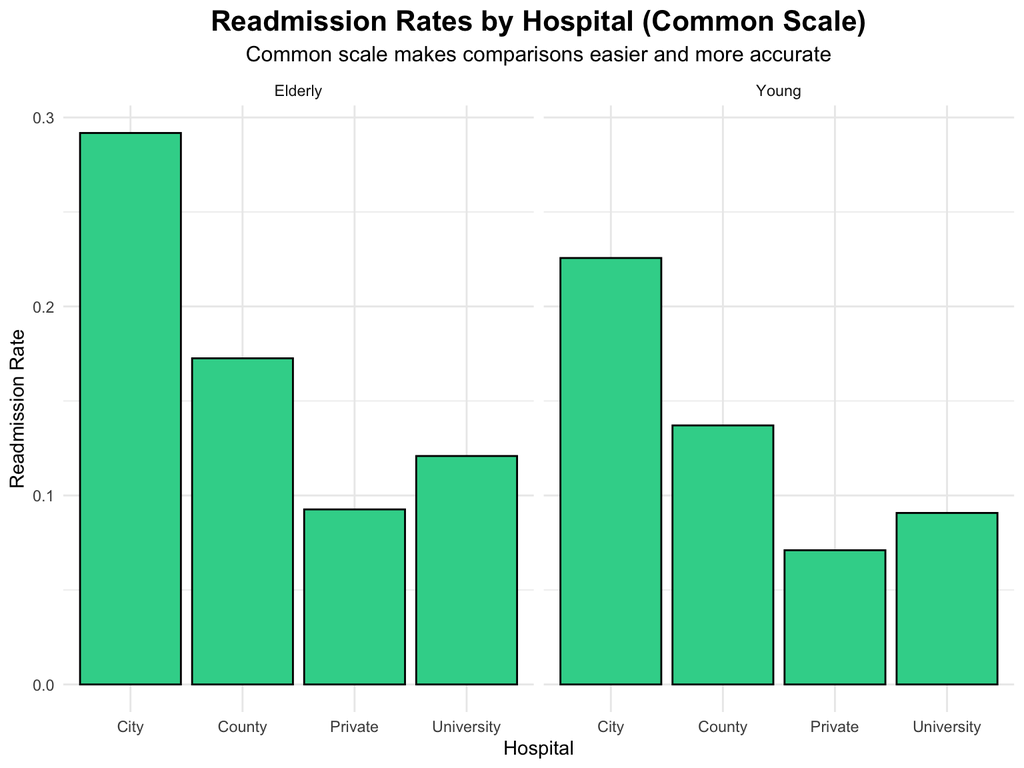

```r
# 3. Position on common scale
ggplot(patient_data, aes(x = hospital, y = readmission_rate)) +
  geom_bar(stat = "summary", fun = "mean", fill = "#34D399", color = "black") +
  facet_wrap(~ age_group, nrow = 1) +
  labs(
    title = "Readmission Rates by Hospital (Common Scale)",
    subtitle = "Common scale makes comparisons easier and more accurate",
    x = "Hospital",
    y = "Readmission Rate"
  ) +
  theme_minimal() +
  theme(
    plot.title = element_text(hjust = 0.5, face = "bold", size = 16),
    plot.subtitle = element_text(hjust = 0.5, size = 12)
  )
```

## Naughty (?) Axes

This section demonstrates how axis scaling can be used to mislead viewers about the magnitude of differences between groups in health outcomes. We’ll use a simulated dataset of treatment effects on adverse events.

In the below code, we simulate data of a rare adverse event that occurs in 0.001% of patients. This adverse event is in reality 3x more likely in the treatment group.

We use a logistic regression to estimate the treatment effect on the adverse event. We then plot the risk of the adverse event by treatment and age group.

```r
# Force regular decimal notation
options(scipen=999)

set.seed(456)
n <- 1000000

data <- data.frame(
  treatment = rbinom(n, 1, 0.5)  # 1 = new treatment, 0 = standard care
)

base_prob <- 0.00001 # 0.001% baseline risk

data$adverse_event <- rbinom(
  n, 1, ifelse(data$treatment == 1, base_prob * 3, base_prob)
)

model <- glm(adverse_event ~ treatment, data = data, family = "binomial")
model |> tidy(exponentiate = TRUE) |> kable()
```

| term | estimate | std.error | statistic | p.value |
| --- | --- | --- | --- | --- |
| (Intercept) | 0.000010 | 0.4472136 | -25.740124 | 0.0000000 |
| treatment | 2.990595 | 0.5163997 | 2.121365 | 0.0338911 |

Below, we visualize the risk of the adverse event by treatment. We can see the risk of an adverse event is 3x higher in the treatment group, which may be alarming. But note the constrained y-axis.

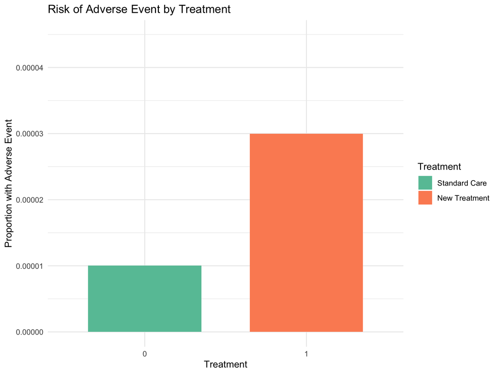

```r
 summary_data <- data |>
  group_by(treatment) |>
  summarize(
    risk = mean(adverse_event),
    n = n(),
    .groups = "drop"
  )

# Plot with constrained axes
ggplot(summary_data, aes(x = factor(treatment), y = risk, fill = factor(treatment))) +
  geom_col(width = 0.7) +
  scale_fill_brewer(palette = "Set2", labels = c("Standard Care", "New Treatment")) +
  labs(
    title = "Risk of Adverse Event by Treatment",
    x = "Treatment",
    y = "Proportion with Adverse Event",
    fill = "Treatment"
  ) +
  scale_y_continuous(limits = c(0, max(summary_data$risk) * 1.5)) +
  theme_minimal()
```

However, if we scale the axis to 0-1, we can see that the absolute risk is vanishingly rare.

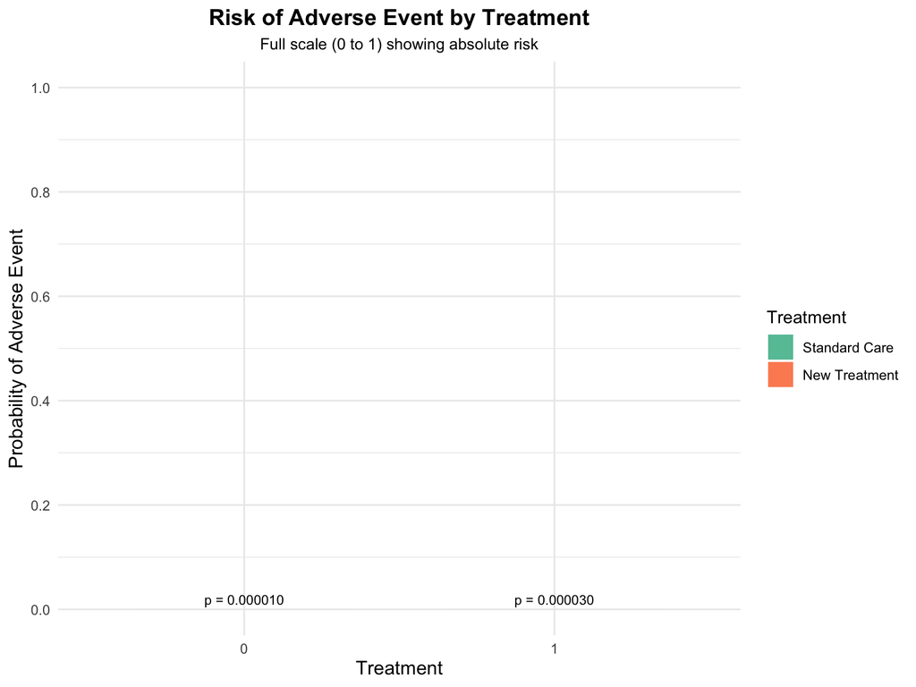

```r
# Now add age group stratification
# Plot with full scale
ggplot(summary_data, aes(x = factor(treatment), y = risk, fill = factor(treatment))) +
  geom_col(width = 0.7) +
  geom_text(
    aes(label = paste0("p = ", sprintf("%.6f", risk))),
    vjust = -0.5,
    size = 3
  ) +
  scale_fill_brewer(palette = "Set2", labels = c("Standard Care", "New Treatment")) +
  labs(
    title = "Risk of Adverse Event by Treatment",
    subtitle = "Full scale (0 to 1) showing absolute risk",
    x = "Treatment",
    y = "Probability of Adverse Event",
    fill = "Treatment"
  ) +
  scale_y_continuous(limits = c(0, 1), breaks = seq(0, 1, 0.2)) +
  theme_minimal() +
  theme(
    plot.title = element_text(hjust = 0.5, size = 14, face = "bold"),
    plot.subtitle = element_text(hjust = 0.5, size = 10),
    axis.title = element_text(size = 12),
    strip.text = element_text(size = 11, face = "bold")
  )
```

I do not believe that the plot with constrained axes is inherently misleading for certain audiences. For example, those who are familiar with medical research will likely understand that an odds ratio of “3” does mean 3x higher odds of the adverse event, but it does not mean that this is necessarily something the public needs to worry about. It is important to consider how an audience will interpret the plot.

## Naughty Time Series Axes

This section demonstrates how time series plots can be misleading when zooming in on specific time periods, using simulated data on Emergency Department bounceback rates as an example. The key technique here is selective windowing, or choosing a specific time period that supports a desired narrative while ignoring the broader context.

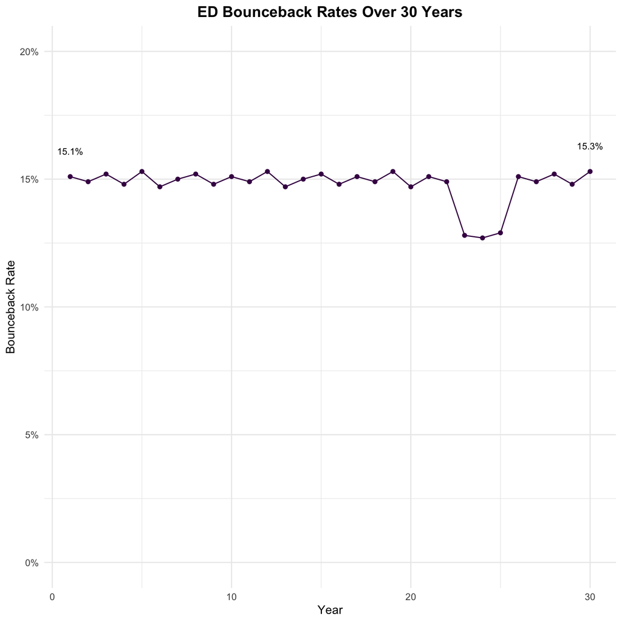

```r
# Create explicit data points
bounceback_data <- data.frame(
  Year = 1:30,
  BouncebackRate = c(
    # First 20 years stable around 15% with noise
    0.151, 0.149, 0.152, 0.148, 0.153, 0.147, 0.150, 0.152, 0.148, 0.151,
    0.149, 0.153, 0.147, 0.150, 0.152, 0.148, 0.151, 0.149, 0.153, 0.147,
    # Year 21-22: Still stable
    0.151, 0.149,
    # Year 23-25: Short dip to 12-13%
    0.128, 0.127, 0.129,
    # Year 26-30: Back to stable around 15%
    0.151, 0.149, 0.152, 0.148, 0.153
  )
)

# Plot showing full scale
ggplot(bounceback_data, aes(x = Year, y = BouncebackRate)) +
  geom_line(color = viridis(1)) +
  geom_point(color = viridis(1)) +
  geom_text(
    data = bounceback_data[c(1, 30), ],
    aes(label = paste0(sprintf("%.1f", BouncebackRate * 100), "%")),
    nudge_y = 0.01,
    size = 3
  ) +
  scale_y_continuous(
    labels = scales::percent,
    limits = c(0, 0.2),
    breaks = seq(0, 0.2, 0.05)
  ) +
  labs(
    title = "ED Bounceback Rates Over 30 Years",
    x = "Year",
    y = "Bounceback Rate"
  ) +
  theme_minimal() +
  theme(
    plot.title = element_text(hjust = 0.5, size = 14, face = "bold")
  )
```

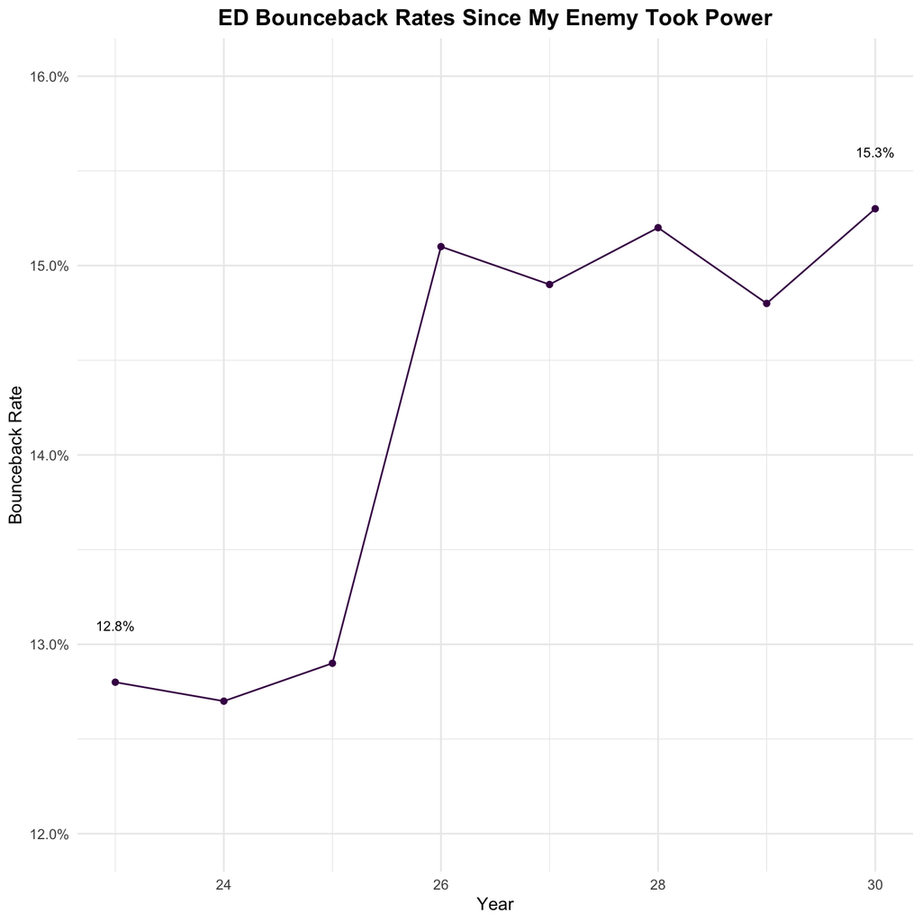

```r
# Misleading plot starting at year 23
ggplot(bounceback_data[bounceback_data$Year >= 23, ], aes(x = Year, y = BouncebackRate)) +
  geom_line(color = viridis(1)) +
  geom_point(color = viridis(1)) +
  geom_text(
    data = bounceback_data[bounceback_data$Year %in% c(23, 30), ],
    aes(label = paste0(sprintf("%.1f", BouncebackRate * 100), "%")),
    nudge_y = 0.003,
    size = 3
  ) +
  scale_y_continuous(
    labels = scales::percent,
    limits = c(0.12, 0.16),
    breaks = seq(0.12, 0.16, 0.01)
  ) +
  labs(
    title = "ED Bounceback Rates Since My Enemy Took Power",
    x = "Year",
    y = "Bounceback Rate"
  ) +
  theme_minimal() +
  theme(
    plot.title = element_text(hjust = 0.5, size = 14, face = "bold"),
    plot.subtitle = element_text(hjust = 0.5, size = 12)
  )
```